# Urban Greenspace and Depression Prevalence Seattle

### Step 5: Explore a linear ordinary least-squares regression

### Step 5a: Data preparation

```python
### Check for missing data
sea_ndvi_cdc_gdf.isnull().sum()
```

```
place2010             0
tract2010             0
ST                    0
PlaceName             0
plctract10            0
PlcTrPop10            0
geometry              0
year                  0
tract_x               0
depression            0
depression_ci_low     0
depression_ci_high    0
data_value_unit       0
totalpopulation       0
totalpop18plus        0
tract_y               0
total_pixels          0
frac_veg              0
mean_patch_size       0
edge_density          0
dtype: int64
```

We do no have missing data in any of our columns.

```python
### Visualize distribution of data
### select variables
variables = ["frac_veg", "depression", "mean_patch_size", "edge_density"]

### scatter plot
hvplot.scatter_matrix(
    sea_ndvi_cdc_gdf[variables],
)
```

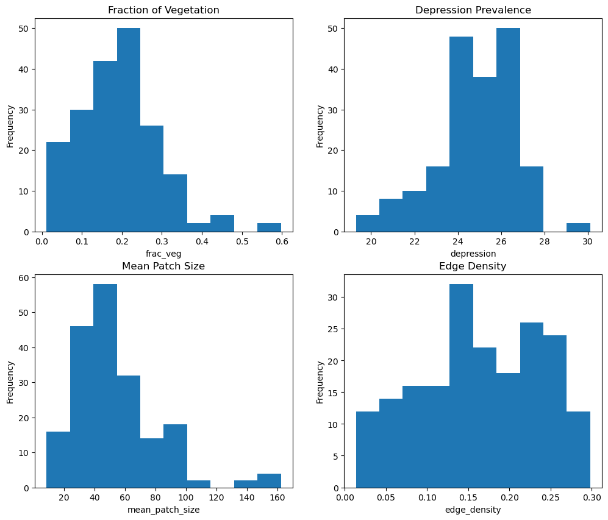

```python
### histograms
fig, axes = plt.subplots(2, 2, figsize=(12, 10))
titles = ["Fraction of Vegetation", "Depression Prevalence", "Mean Patch Size", "Edge Density"]

### loop through variables and axes
for i, (var, title) in enumerate(zip(variables, titles)):
    ax = axes[i // 2, i % 2]
    ax.hist(sea_ndvi_cdc_gdf[var], bins=10)
    ax.set_title(title)
    ax.set_xlabel(var)
    ax.set_ylabel("Frequency")
```

```python
### Drop missing values for modeling
### this is not needed for this data but good practice
model_df = (
    sea_ndvi_cdc_gdf
    ### copy
    .copy()

    ### subset of data
    [["frac_veg", "depression", "mean_patch_size", "edge_density", "geometry"]]

    ### drop rows with missing values
    .dropna()
)

model_df
```

|  | frac_veg | depression | mean_patch_size | edge_density | geometry |
| --- | --- | --- | --- | --- | --- |
| 0 | 0.190969 | 24.8 | 44.339429 | 0.138175 | POLYGON ((-13617001.301 6062724.988, -13616999... |
| 1 | 0.190969 | 24.8 | 44.339429 | 0.138175 | POLYGON ((-13617001.301 6062724.988, -13616999... |
| 2 | 0.196802 | 24.2 | 38.601075 | 0.172093 | POLYGON ((-13619382.313 6060935.151, -13619381... |
| 3 | 0.196802 | 24.2 | 38.601075 | 0.172093 | POLYGON ((-13619382.313 6060935.151, -13619381... |
| 4 | 0.467664 | 23.9 | 134.543969 | 0.213793 | POLYGON ((-13621158.194 6062739.387, -13621158... |
| ... | ... | ... | ... | ... | ... |
| 187 | 0.597151 | 21.7 | 162.250000 | 0.043970 | MULTIPOLYGON (((-13607978.18 6024438.851, -136... |
| 188 | 0.446520 | 24.6 | 151.691489 | 0.159953 | POLYGON ((-13618200.317 6027503.983, -13617926... |
| 189 | 0.446520 | 24.6 | 151.691489 | 0.159953 | POLYGON ((-13618200.317 6027503.983, -13617926... |
| 190 | 0.297510 | 26.3 | 89.043339 | 0.059210 | POLYGON ((-13617822.498 6027531.841, -13617709... |
| 191 | 0.297510 | 26.3 | 89.043339 | 0.059210 | POLYGON ((-13617822.498 6027531.841, -13617709... |

192 rows × 5 columns

```python
### Perform variable transformation

### log of depression rate and patch size
model_df['log_depression'] = np.log(model_df['depression'])
model_df['log_patch'] = np.log(model_df['mean_patch_size'])
model_df
```

|  | frac_veg | depression | mean_patch_size | edge_density | geometry | log_depression | log_patch |
| --- | --- | --- | --- | --- | --- | --- | --- |
| 0 | 0.190969 | 24.8 | 44.339429 | 0.138175 | POLYGON ((-13617001.301 6062724.988, -13616999... | 3.210844 | 3.791874 |
| 1 | 0.190969 | 24.8 | 44.339429 | 0.138175 | POLYGON ((-13617001.301 6062724.988, -13616999... | 3.210844 | 3.791874 |
| 2 | 0.196802 | 24.2 | 38.601075 | 0.172093 | POLYGON ((-13619382.313 6060935.151, -13619381... | 3.186353 | 3.653280 |
| 3 | 0.196802 | 24.2 | 38.601075 | 0.172093 | POLYGON ((-13619382.313 6060935.151, -13619381... | 3.186353 | 3.653280 |
| 4 | 0.467664 | 23.9 | 134.543969 | 0.213793 | POLYGON ((-13621158.194 6062739.387, -13621158... | 3.173878 | 4.901891 |
| ... | ... | ... | ... | ... | ... | ... | ... |
| 187 | 0.597151 | 21.7 | 162.250000 | 0.043970 | MULTIPOLYGON (((-13607978.18 6024438.851, -136... | 3.077312 | 5.089138 |
| 188 | 0.446520 | 24.6 | 151.691489 | 0.159953 | POLYGON ((-13618200.317 6027503.983, -13617926... | 3.202746 | 5.021849 |
| 189 | 0.446520 | 24.6 | 151.691489 | 0.159953 | POLYGON ((-13618200.317 6027503.983, -13617926... | 3.202746 | 5.021849 |
| 190 | 0.297510 | 26.3 | 89.043339 | 0.059210 | POLYGON ((-13617822.498 6027531.841, -13617709... | 3.269569 | 4.489123 |
| 191 | 0.297510 | 26.3 | 89.043339 | 0.059210 | POLYGON ((-13617822.498 6027531.841, -13617709... | 3.269569 | 4.489123 |

192 rows × 7 columns

```python
### Visualize transformed variables
### scatter plot
scatter_log = hvplot.scatter_matrix(
    model_df[["frac_veg", "edge_density", "log_depression", "log_patch"]],
)

# Export plot
#hv.save(scatter_log, 'scatter_log.html')
scatter_log
```

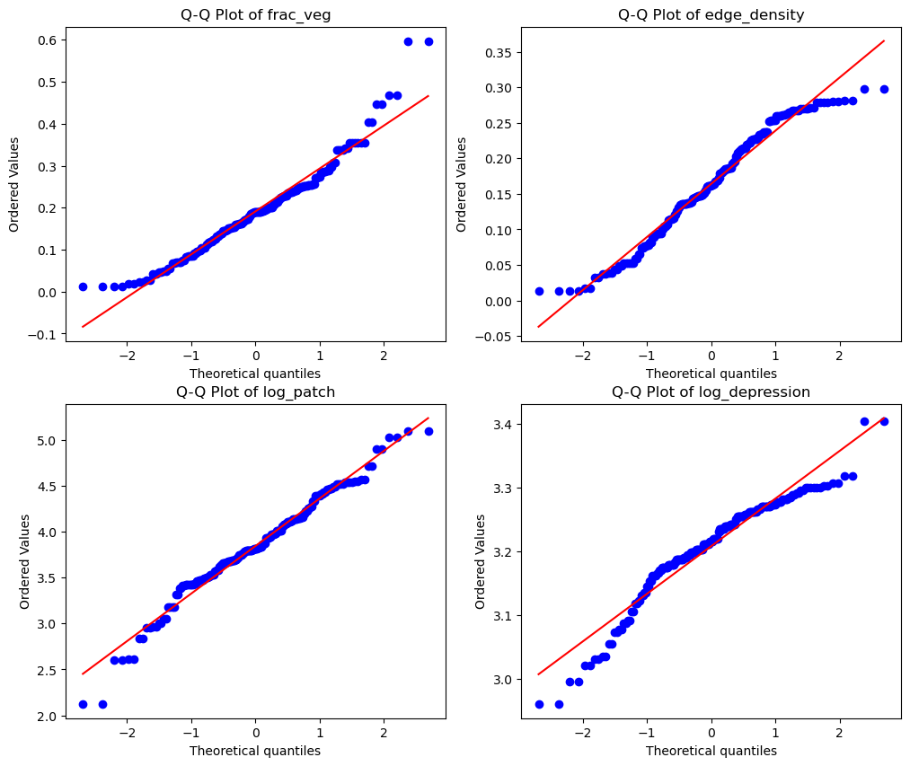

```python
### q-q plots
fig, axes = plt.subplots(2, 2, figsize=(12, 10))
vars_qq = ["frac_veg", "edge_density", "log_patch", "log_depression"]

plt.figure(figsize=(12, 10))
for i, var in enumerate(vars_qq):
    ax = axes[i // 2, i % 2]
    stats.probplot(model_df[var], dist="norm", plot=ax)
    ax.set_title(f"Q-Q Plot of {var}")
```

We used Q-Q plots to compare the distributions after transformation. Deviations from the line indicate non-normality with curves signify skewness and while s-shapes indicate heavy or light tails.

The two variables that best follow the red line are log_patch and edge_density. It can be seen that the transformation from mean_patch_size to log_patch probably leads to better model results when used for this purpose.

#### Step 5b: Fit and Predict

```python
### Select predictor and outcome variables
X = model_df[['edge_density', 'log_patch']]
y = model_df[['log_depression']]

### Split into training and testing datasets
### choose ratio of train and test data
train_test_split_size = 0.25
X_train, X_test, y_train, y_test = train_test_split(
    X, y, test_size=train_test_split_size, random_state=19
)

### Fit a linear regression
model = LinearRegression()
model.fit(X_train, y_train)

### Predict depression values for the test dataset
y_test['predicted_depression'] = np.exp(model.predict(X_test))

### real depression values for comparison
y_test['real_depression'] = np.exp(y_test['log_depression'])
y_test
```

|  | log_depression | predicted_depression | real_depression |
| --- | --- | --- | --- |
| 142 | 3.277145 | 23.974939 | 26.5 |
| 72 | 3.273364 | 24.923957 | 26.4 |
| 96 | 3.280911 | 24.066180 | 26.6 |
| 34 | 3.218876 | 25.568939 | 25.0 |
| 152 | 3.030134 | 25.084134 | 20.7 |
| 16 | 3.261935 | 25.290568 | 26.1 |
| 115 | 3.214868 | 24.240011 | 24.9 |
| 59 | 3.210844 | 26.125226 | 24.8 |
| 183 | 3.238678 | 25.649716 | 25.5 |
| 176 | 3.182212 | 24.863649 | 24.1 |
| 62 | 3.202746 | 23.785511 | 24.6 |
| 151 | 2.960105 | 25.197535 | 19.3 |
| 173 | 3.194583 | 25.086987 | 24.4 |
| 130 | 3.190476 | 23.885179 | 24.3 |
| 136 | 3.190476 | 24.818438 | 24.3 |
| 147 | 3.122365 | 25.715929 | 22.7 |
| 41 | 3.210844 | 25.431118 | 24.8 |
| 144 | 3.173878 | 24.547156 | 23.9 |
| 145 | 3.173878 | 24.547156 | 23.9 |
| 125 | 3.202746 | 24.808109 | 24.6 |
| 157 | 3.273364 | 25.319401 | 26.4 |
| 33 | 3.258097 | 25.555341 | 26.0 |
| 1 | 3.210844 | 24.670599 | 24.8 |
| 138 | 3.242592 | 24.190689 | 25.6 |
| 20 | 3.210844 | 25.588316 | 24.8 |
| 135 | 3.169686 | 24.270928 | 23.8 |
| 30 | 3.194583 | 25.355611 | 24.4 |
| 180 | 2.995732 | 24.688845 | 20.0 |
| 31 | 3.194583 | 25.355611 | 24.4 |
| 8 | 3.173878 | 25.410318 | 23.9 |
| 26 | 3.254243 | 24.741480 | 25.9 |
| 13 | 3.218876 | 25.495444 | 25.0 |
| 129 | 3.202746 | 24.159487 | 24.6 |
| 99 | 3.234749 | 26.023307 | 25.4 |
| 37 | 3.131137 | 23.746888 | 22.9 |
| 146 | 3.122365 | 25.715929 | 22.7 |
| 7 | 3.234749 | 25.467705 | 25.4 |
| 190 | 3.269569 | 23.539107 | 26.3 |
| 191 | 3.269569 | 23.539107 | 26.3 |
| 60 | 3.161247 | 26.149654 | 23.6 |
| 166 | 3.034953 | 24.770413 | 20.8 |
| 181 | 2.995732 | 24.688845 | 20.0 |
| 2 | 3.186353 | 25.088252 | 24.2 |
| 134 | 3.169686 | 24.270928 | 23.8 |
| 58 | 3.210844 | 26.125226 | 24.8 |
| 94 | 3.254243 | 25.252868 | 25.9 |
| 78 | 3.144152 | 24.780944 | 23.2 |
| 61 | 3.161247 | 26.149654 | 23.6 |

```python
### Plot measured vs. predicted asthma prevalence with a 1-to-1 line
y_max = y_test.real_depression.max()
(
    y_test
    .hvplot.scatter(x='real_depression',
                    y='predicted_depression',
                    xlabel='Measured Depression Prevalence',
                    ylabel='Predicted Depression Prevalence',
                    title='Measured vs. Predicted Depression Prevalence in Test Dataset')
    .opts(aspect='equal',
          xlim=(0, y_max), ylim=(0, y_max),
          width=600, height=600)
) * hv.Slope(slope=1, y_intercept=0).opts(color='black')
```

#### Step 5c: Expore spatial bias

```python
### Compute model error for all census tracts
### use trained model to predict depression for all tracts
model_df['pred_depression'] = np.exp(model.predict(X))

### calcuate model error
model_df['error_depression'] = model_df['pred_depression'] - model_df['depression']

### Plot error geographically as a chloropleth
error_chloropleth =(
    plot_chloropleth(
        model_df,
        color='error_depression',
        cmap='RdBu',
        title='Model Error in Depression Prevalence Predictions',
    ).opts(
        frame_width=600,
        aspect="equal")
)

# Export plot
#hv.save(error_chloropleth, 'error_chloropleth.html')
error_chloropleth
```

[output not shown]

### Limited use of vegetation data to estimate depression prevalence

However, other factors may be more important. These include the crime rate and financial security and income. A seasonal factor can also be decisive: due to limited sunlight and a humid, cloudy climate, the city has high rates of seasonal affective disorder (SAD).

##### Citations

Centers for Disease Control and Prevention. PLACES: Local Data for Better Health. Accessed [2026-01-30]. https://www.cdc.gov/places

Ziquan Liu, Xuemei Chen, Huanhuan Cui, Yuxuan Ma, Ning Gao, Xinyu Li, Xiangyan Meng, Huishu Lin, Halidan Abudou, Liqiong Guo, Qisijing Liu (2023): Green space exposure on depression and anxiety outcomes: A meta-analysis. https://doi.org/10.1016/j.envres.2023.116303

Cascade PBS. Accessed [2026-01-30]: Climate change takes a toll on Seattleites' mental health. https://www.cascadepbs.org/environment/2022/06/climate-change-takes-toll-seattleites-mental-health/

Microsoft Planetary Computer SpatioTemporal Assess cataloc (STAC). Accessed [2026-01-30]. https://planetarycomputer.microsoft.com/catalog